# CSCI E-106:Assignment 9

### Due Date: November 23, 2020 at 7:20 pm EST

### Instructions

Students should submit their reports on Canvas. The report needs to clearly state what question is being solved, step-by-step walk-through solutions, and final answers clearly indicated. Please solve by hand where appropriate.

Please submit two files: (1) a R Markdown file (.Rmd extension) and (2) a PDF document, word, or html generated using knitr for the .Rmd file submitted in (1) where appropriate. Please, use RStudio Cloud for your solutions.

## Problem 1

Refer to Brand preference data, build a model with all independent variables (45 pts, 5 points each)

a-) Obtain the studentized deleted residuals and identify any outlying Y observations. Use the Bonferroni outlier test procedure with $\alpha$= 0.10. State the decision rule and conclusion.

```r
rm(list=ls())
setwd("~/OneDrive/courses/e106/e106_hes2020/HW/HW9") # change before run if needed

library(olsrr) # regression plots
library(caret) # cross validation
library(car) # regression diagnostics
library(MASS) # studentized residuals
brand <- read.csv('Brand Preference.csv')
head(brand)
```

|  | Y | X1 | X2 |
| --- | --- | --- | --- |
| 1 | 64 | 4 | 2 |
| 2 | 73 | 4 | 4 |
| 3 | 61 | 4 | 2 |
| 4 | 76 | 4 | 4 |
| 5 | 72 | 6 | 2 |
| 6 | 80 | 6 | 4 |

```r
str(brand)
```

```
## 'data.frame':    16 obs. of  3 variables:
##  $ Y : int  64 73 61 76 72 80 71 83 83 89 ...
##  $ X1: int  4 4 4 4 6 6 6 6 8 8 ...
##  $ X2: int  2 4 2 4 2 4 2 4 2 4 ...
```

```r
f1 <- lm(Y~., data = brand)
summary(f1)
```

```
##
## Call:
## lm(formula = Y ~ ., data = brand)
##
## Residuals:
##    Min     1Q Median     3Q    Max
## -4.400 -1.762  0.025  1.587  4.200
##
## Coefficients:
##             Estimate Std. Error t value Pr(>|t|)
## (Intercept)  37.6500     2.9961  12.566 1.20e-08 ***
## X1            4.4250     0.3011  14.695 1.78e-09 ***
## X2            4.3750     0.6733   6.498 2.01e-05 ***
## ---
## Signif. codes:  0 '***' 0.001 '**' 0.01 '*' 0.05 '.' 0.1 ' ' 1
##
## Residual standard error: 2.693 on 13 degrees of freedom
## Multiple R-squared:  0.9521, Adjusted R-squared:  0.9447
## F-statistic: 129.1 on 2 and 13 DF,  p-value: 2.658e-09
```

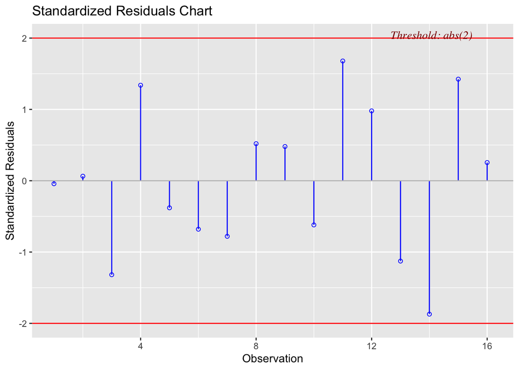

```r
# plot of residuals
ols_plot_resid_stand(f1)
```

```r
# studentized deleted residuals
studres(f1)
```

```
##           1           2           3           4           5           6
## -0.04085498  0.06128781 -1.36059879  1.38602483 -0.36694571 -0.66490618
##           7           8           9          10          11          12
## -0.76716157  0.50461264  0.46506694 -0.60436295  1.82302030  0.97784298
##          13          14          15          16
## -1.13966417 -2.10272640  1.48973208  0.24572878
```

```r
# rstudent(f1)

# test for outliers
outlierTest(f1, cutoff = 0.90, n.max = Inf)
```

```
## No Studentized residuals with Bonferroni p < 0.9
## Largest |rstudent|:
##     rstudent unadjusted p-value Bonferroni p
## 14 -2.102726           0.057267      0.91627
```

Ho : There are no outliers Ha : Outliers are present in the data

Decision Rule: if |t*| < t(1-alpha/2n; n-p-1) accept Ho; else reject

From the test results we see that there are no outliers

b-) Obtain the diagonal elements of the hat matrix, and provide an explanation for the pattern in these elements.

```r
hii_brand <- hatvalues(f1)
hii_brand
```

```
##      1      2      3      4      5      6      7      8      9     10     11
## 0.2375 0.2375 0.2375 0.2375 0.1375 0.1375 0.1375 0.1375 0.1375 0.1375 0.1375
##     12     13     14     15     16
## 0.1375 0.2375 0.2375 0.2375 0.2375
```

The hat values are a function of the predictor variables. since the predictor variables are comprised of combinations of 4 unique values of X1and 2 unique values of X2 we see the above pattern.

c-) Are any of the observations outlying with regard to their X values according?

```r
influence.measures(f1)
```

```
## Influence measures of
##   lm(formula = Y ~ ., data = brand) :
##
##      dfb.1_  dfb.X1  dfb.X2   dffit cov.r   cook.d   hat inf
## 1  -0.02155  0.0157  0.0117 -0.0228 1.667 0.000188 0.238
## 2   0.00868 -0.0235  0.0175  0.0342 1.666 0.000422 0.237
## 3  -0.71785  0.5226  0.3895 -0.7593 1.084 0.180392 0.237
## 4   0.19619 -0.5324  0.3968  0.7735 1.068 0.186258 0.238
## 5  -0.11987  0.0442  0.0988 -0.1465 1.426 0.007666 0.138
## 6   0.02413  0.0800 -0.1790 -0.2655 1.322 0.024547 0.138
## 7  -0.25062  0.0924  0.2065 -0.3063 1.277 0.032297 0.138
## 8  -0.01832 -0.0607  0.1358  0.2015 1.384 0.014354 0.138
## 9   0.07315  0.0560 -0.1252  0.1857 1.397 0.012231 0.138
## 10  0.12431 -0.0728 -0.1627 -0.2413 1.347 0.020406 0.138
## 11  0.28674  0.2195 -0.4907  0.7279 0.708 0.149828 0.138
## 12 -0.20113  0.1177  0.2632  0.3904 1.171 0.050983 0.138
## 13  0.01467 -0.4378  0.3263 -0.6360 1.225 0.131821 0.237
## 14  0.83881 -0.8077 -0.6020 -1.1735 0.651 0.363412 0.237
## 15 -0.01917  0.5722 -0.4265  0.8314 1.002 0.210661 0.237
## 16 -0.09802  0.0944  0.0704  0.1371 1.643 0.006758 0.237
```

From the table above we see that none of the observations are outlying

d-) Management wishes to estimate the mean degree of brand liking for moisture content $X_1$ = 10 and sweetness $X_2$ = 3. Construct a scatter plot of $X_2$ against $X_1$ and determine visually whether this prediction involves an extrapolation beyond the range of the data. Also, determine whether an extrapolation is involved. Do your conclusions from the two methods agree?

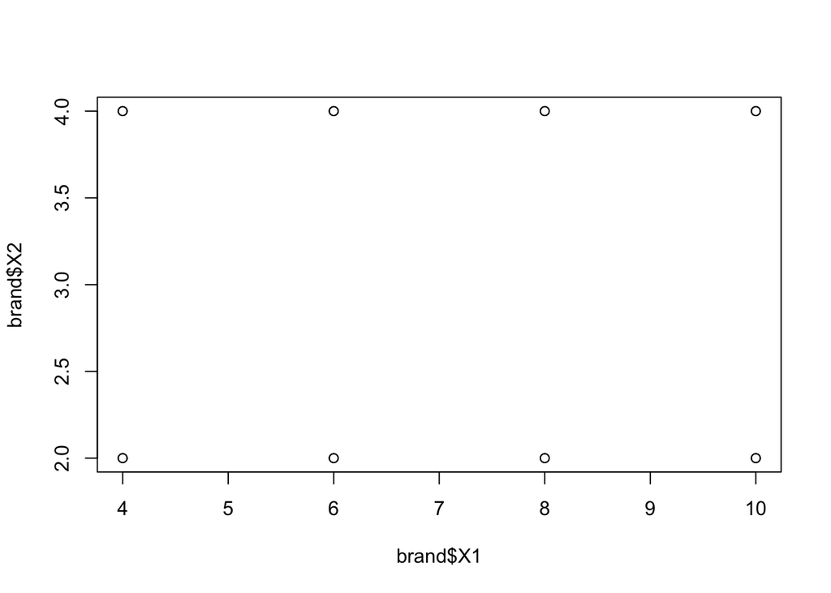

```r
plot(brand$X1, brand$X2)
```

```r
x <- model.matrix(f1)
xnew <- matrix(c(10,3), nrow(x), ncol(x), byrow = TRUE)

xx_inv <- solve(t(x)%*%x)
#hat_datat <- t(xnew)%*%xx_inv%*%xnew
#hat_datat
```

We see that there is no visual extrapolation needed beyond the range of the data

e-) The largest absolute studentized deleted residual is for case 14. Obtain the DFFITS, DFBETAS, and Cook’s distance values for this case to assess the influence of this case. What do you conclude?

```r
# max cooks distance value and all other influence measures
which.max(influence.measures(f1)$infmat[,6])
```

```
## 14
## 14
```

```r
influence.measures(f1)$infmat[14,]
```

```
##     dfb.1_     dfb.X1     dfb.X2      dffit      cov.r     cook.d        hat
##  0.8388068 -0.8076796 -0.6020088 -1.1735312  0.6506614  0.3634123  0.2375000
```

f-) Calculate the average absolute percent difference in the fitted values with and without case 14. What does this measure indicate about the influence of case 14?

```r
# predict fitted values
predict_full <- predict(f1, brand)

# fit without row 14
f1f <- lm(Y~., data = brand[-c(14),])
summary(f1f)
```

```
##
## Call:
## lm(formula = Y ~ ., data = brand[-c(14), ])
##
## Residuals:
##     Min      1Q  Median      3Q     Max
## -3.2992 -1.9693  0.0779  1.2480  3.9836
##
## Coefficients:
##             Estimate Std. Error t value Pr(>|t|)
## (Intercept)  35.4139     2.8700  12.339 3.54e-08 ***
## X1            4.6414     0.2870  16.172 1.64e-09 ***
## X2            4.7357     0.6232   7.599 6.34e-06 ***
## ---
## Signif. codes:  0 '***' 0.001 '**' 0.01 '*' 0.05 '.' 0.1 ' ' 1
##
## Residual standard error: 2.396 on 12 degrees of freedom
## Multiple R-squared:  0.9613, Adjusted R-squared:  0.9548
## F-statistic:   149 on 2 and 12 DF,  p-value: 3.369e-09
```

```r
# predict fitted values
predict_less14 <- predict(f1f, brand)

# get average absolute fitted values
sum(abs((predict_less14-predict_full)/predict_full)*100)/length(predict_full)
```

```
## [1] 0.677679
```

g-) Calculate Cook’s distance D; for each case and prepare an index plot. Are any cases influential according to this measure?

```r
# calculate coks distance
influence.measures(f1)$infmat[,6]
```

```
##            1            2            3            4            5            6
## 0.0001877130 0.0004223542 0.1803921815 0.1862582123 0.0076655286 0.0245466787
##            7            8            9           10           11           12
## 0.0322971439 0.0143542862 0.0122308711 0.0204060192 0.1498281704 0.0509831969
##           13           14           15           16
## 0.1318214458 0.3634123447 0.2106609008 0.0067576676
```

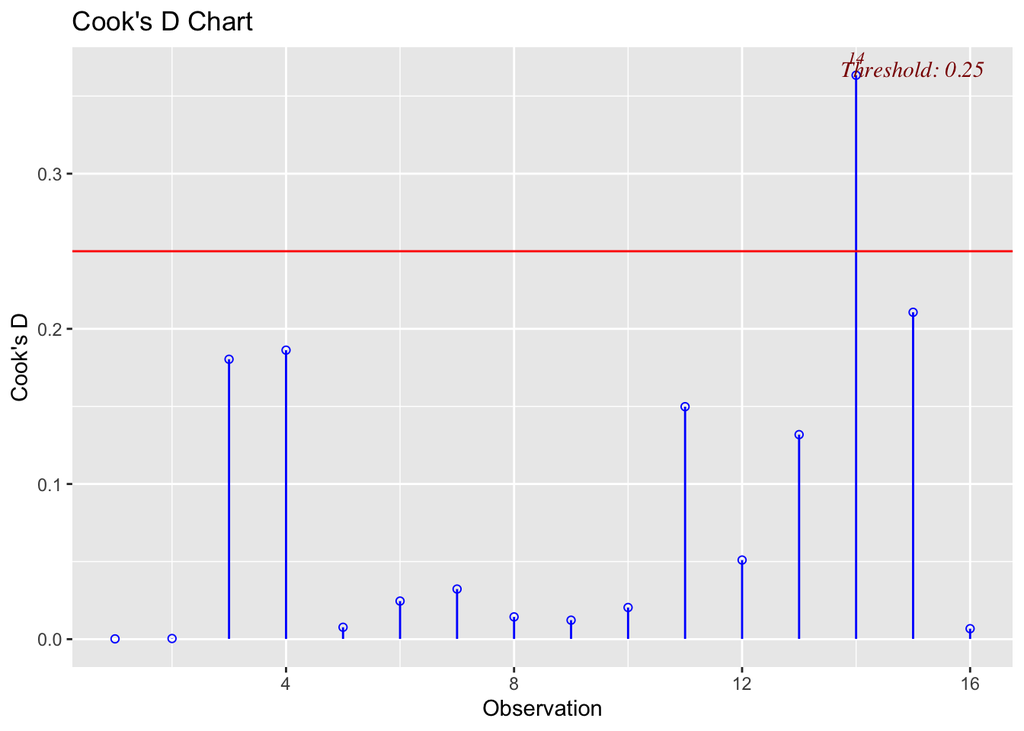

```r
ols_plot_cooksd_chart(f1)
```

As per this measure point 14 is influential

h-) Find the two variance inflation factors. Why are they both equal to 1?

```r
vif(f1)
```

```
## X1 X2
##  1  1
```

VIF 1 indicates that the predictors are not correlated.

## Problem 2

Refer to the Lung pressure Data. Increased arterial blood pressure in the lungs frequently leads to the development of heart failure in patients with chronic obstructive pulmonary disease (COPD). The standard method for determining arterial lung pressure is invasive, technically difficult, and involves some risk to the patient. Radionuclide imaging is a noninvasive, less risky method for estimating arterial pressure in the lungs. To investigate the predictive ability of this method, a cardiologist collected data on 19 mild-to-moderate COPD patients. The data includes the invasive measure of systolic pulmonary arterial pressure (Y) and three potential noninvasive predictor variables. Two were obtained by using radionuclide imaging emptying rate of blood into the pumping chamber or the heart ($X_1$) and ejection rate of blood pumped out of the heart into the lungs ($X_2$) and the third predictor variable measures blood gas ($X_3$). (35 points, 5 points each)

a-) Find the best regression model by using first-order terms and the cross-product term. Ensure that all variables in the model are significant at 5%.

```r
lung <- read.csv('Lung Pressure.csv')
head(lung)
```

|  | Y | X1 | X2 | X3 |
| --- | --- | --- | --- | --- |
| 1 | 49 | 45 | 36 | 45 |
| 2 | 55 | 30 | 28 | 40 |
| 3 | 85 | 11 | 16 | 42 |
| 4 | 32 | 30 | 46 | 40 |
| 5 | 26 | 39 | 76 | 43 |
| 6 | 28 | 42 | 78 | 27 |

```r
str(lung)
```

```
## 'data.frame':    19 obs. of  4 variables:
##  $ Y : int  49 55 85 32 26 28 95 26 74 37 ...
##  $ X1: int  45 30 11 30 39 42 17 63 25 32 ...
##  $ X2: int  36 28 16 46 76 78 24 80 12 27 ...
##  $ X3: int  45 40 42 40 43 27 36 42 52 35 ...
```

```r
f2a <- lm(Y~.^3, data = lung)
#summary(f2a)

b2 <- ols_step_best_subset(f2a, details = TRUE, print_plot = TRUE)
b2
```

|  | mindex | n | predictors | rsquare | adjr | predrsq | cp | aic | sbic | sbc | msep | fpe | apc | hsp |
| --- | --- | --- | --- | --- | --- | --- | --- | --- | --- | --- | --- | --- | --- | --- |
| 2 | 1 | 1 | X2 | 0.5588617 | 0.5329124 | 0.45689562 | 10.960492 | 159.3896 | 42.84554 | 162.2230 | 3990.288 | 231.9614 | 0.5449355 | 13.116864 |
| 8 | 2 | 2 | X1 X2 | 0.6134592 | 0.5651416 | 0.38264534 | 9.747493 | 158.8793 | 30.83953 | 162.6571 | 3729.526 | 226.2396 | 0.5314936 | 13.025916 |
| 30 | 3 | 3 | X1 X2 X1:X2 | 0.7922193 | 0.7506631 | 0.36910317 | 1.227662 | 149.0850 | -251.39601 | 153.8072 | 2147.963 | 135.6165 | 0.3185971 | 8.002213 |
| 70 | 4 | 4 | X1 X2 X1:X2 X1:X2:X3 | 0.7967238 | 0.7386449 | 0.29982880 | 2.962576 | 150.6686 | -237.97592 | 156.3352 | 2263.042 | 148.3339 | 0.3484735 | 9.033152 |
| 106 | 5 | 5 | X1 X2 X1:X2 X1:X3 X1:X2:X3 | 0.8022028 | 0.7261270 | 0.25623547 | 4.640141 | 152.1494 | -228.99177 | 158.7605 | 2385.549 | 161.9151 | 0.3803791 | 10.254621 |
| 121 | 6 | 6 | X1 X2 X3 X1:X2 X1:X3 X1:X2:X3 | 0.8042226 | 0.7063338 | 0.08847600 | 6.521283 | 153.9544 | -203.91087 | 161.5099 | 2575.843 | 180.5616 | 0.4241845 | 11.995350 |
| 127 | 7 | 7 | X1 X2 X3 X1:X2 X1:X3 X2:X3 X1:X2:X3 | 0.8130805 | 0.6941318 | 0.07611253 | 8.000000 | 155.0747 | -211.92711 | 163.5747 | 2705.229 | 195.2973 | 0.4588023 | 13.743141 |

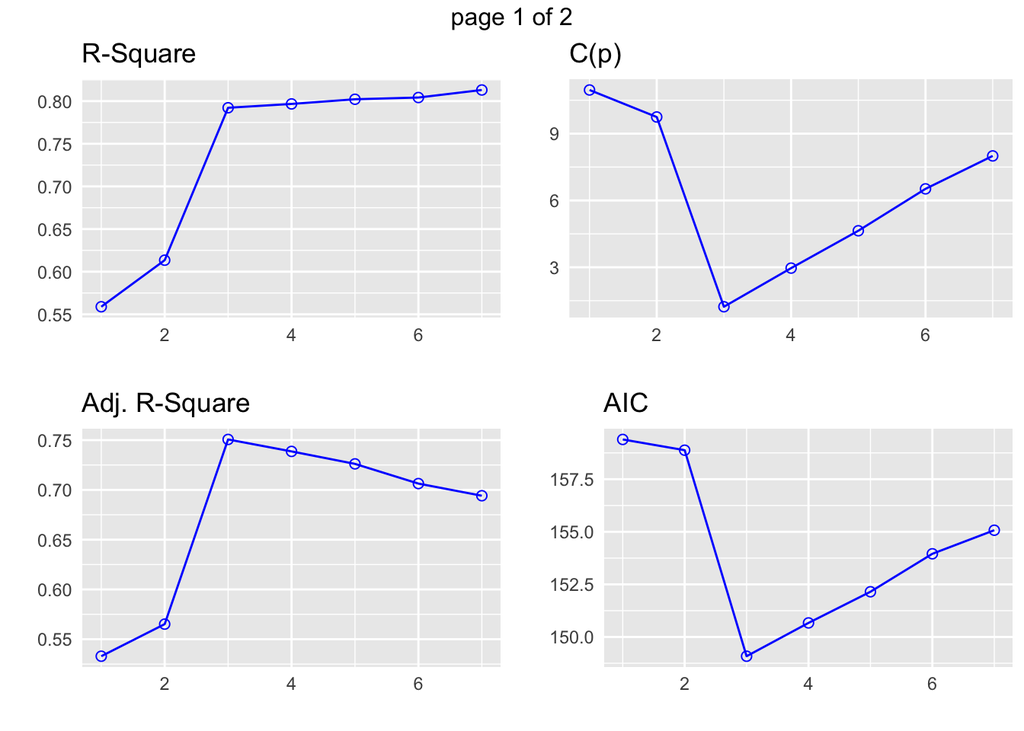

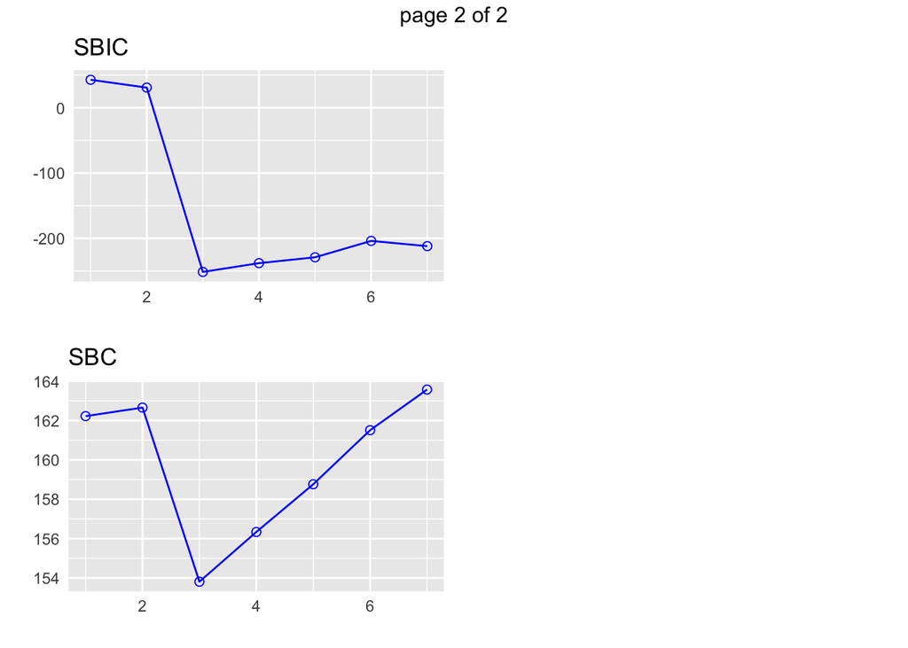

```r
plot(b2)
```

```r
which.max(b2$rsquare)
```

```
## [1] 7
```

```r
which.min(b2$aic)
```

```
## [1] 3
```

```r
which.min(b2$cp)
```

```
## [1] 3
```

Choosing model 3 since it has minimum AIC & Cp even though model 7 has highest R2 since the difference is only 2%. We include X1 & X2

```r
f2b <- lm(Y~X1*X2, data = lung)

# perform 10 fold CV for the chosen model
#control2b <- trainControl(method = 'cv', number = 10)
#f2b <- train(Y~X1*X2, data = lung, method = 'lm', trControl = control2b, metric = 'Rsquared')

summary(f2b)
```

```
##
## Call:
## lm(formula = Y ~ X1 * X2, data = lung)
##
## Residuals:
##      Min       1Q   Median       3Q      Max
## -14.3075  -6.6602  -0.5824   4.6284  24.0398
##
## Coefficients:
##               Estimate Std. Error t value Pr(>|t|)
## (Intercept) 134.399866  15.981599   8.410 4.63e-07 ***
## X1           -2.133022   0.522157  -4.085 0.000975 ***
## X2           -1.699330   0.363669  -4.673 0.000300 ***
## X1:X2         0.033347   0.009283   3.592 0.002667 **
## ---
## Signif. codes:  0 '***' 0.001 '**' 0.01 '*' 0.05 '.' 0.1 ' ' 1
##
## Residual standard error: 10.58 on 15 degrees of freedom
## Multiple R-squared:  0.7922, Adjusted R-squared:  0.7507
## F-statistic: 19.06 on 3 and 15 DF,  p-value: 2.233e-05
```

As seen from the summary; all variables are significant at 5% LOS

b-) Obtain the residuals and plot them separately against Y and each of the three predictor variables. On the basis of these plots. should any further modification of the regression model be attempted?

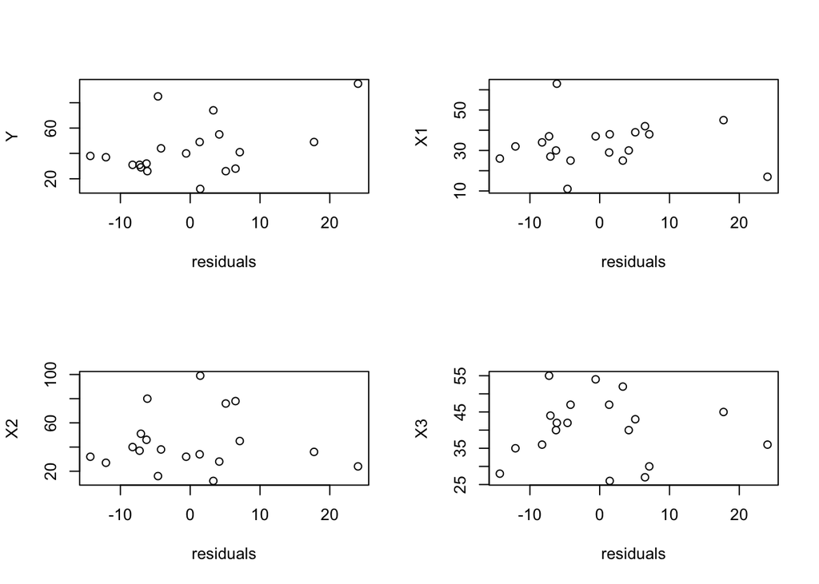

```r
#pred2b <- predict(f2b, lung)
#e2b <- lung$Y-pred2b

e2b <- f2b$residuals
newer.par = par(mfrow=c(2,2))
for (i in 1:ncol(lung)) {
  #print(i)
  plot(e2b, lung[,i], xlab = 'residuals', ylab = colnames(lung[i]))
}
```

```r
newer.par
```

```
## $mfrow
## [1] 1 1
```

From the plots above there doesn’t appear to be any need for further modification.

c-) Prepare a normal probability plot of the residuals. Also obtain the coefficient of correlation between the ordered residuals and their expected values under normality. Does the normality assumption appear to be reasonable here?

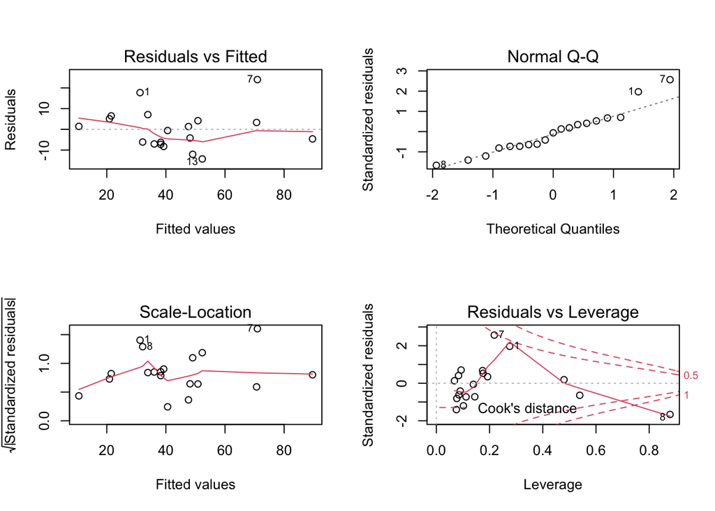

```r
newer.par = par(mfrow = c(2,2))
plot(f2b)
```

```r
newer.par
```

```
## $mfrow
## [1] 1 1
```

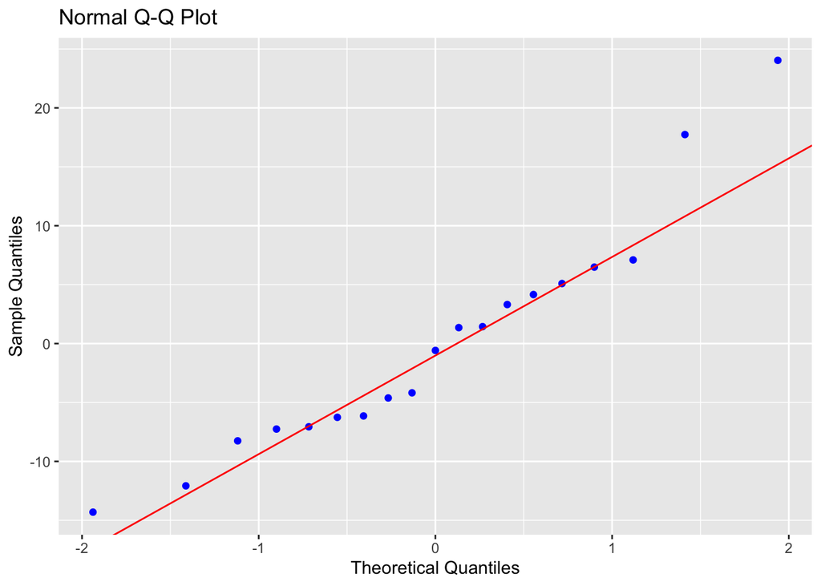

```r
ols_plot_resid_qq(f2b)
```

```r
ols_test_correlation(f2b)
```

```
## [1] 0.9633751
```

There is a high amount of correlation 0.9633751

d-) Obtain the variance inflation factors. Are there any indications that serious multicollinearity problems are present? Explain.

```r
vif(f2b)
```

```
##        X1        X2     X1:X2
##  5.431477 11.639560 22.474469
```

High VIF values as seen above point to existence of serious multicolinearity problems; especially in the interaction variables.

e-) Obtain the studentized deleted residuals and identify outlying Y observations. Use the Bonferroni outlier test procedure with $\alpha$= .05. State the decision rule and conclusion.

```r
# studentized deleted residuals
studres(f2b)
```

```
##           1           2           3           4           5           6
##  2.20949767  0.39888745 -0.62921335 -0.60493125  0.51720509  0.66177537
##           7           8           9          10          11          12
##  3.31413942 -1.77940768  0.33794360 -1.22323837 -0.71526090  0.12816018
##          13          14          15          16          17          18
## -1.45742667  0.69211126  0.18206256 -0.40213241 -0.70921384 -0.05730045
##          19
## -0.80209657
```

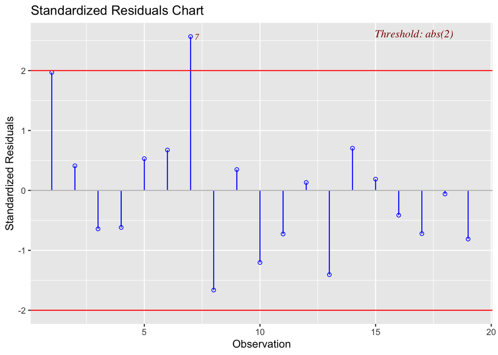

```r
# rstudent(f2b)

# plots and outlier tests
ols_plot_resid_stand(f2b)
```

```r
outlierTest(f2b, cutoff = 0.95)
```

```
##   rstudent unadjusted p-value Bonferroni p
## 7 3.314139          0.0051163      0.09721
## 1 2.209498          0.0443040      0.84178
```

f-) Obtain the diagonal elements of the hat matrix. Are there any outlying X observations? Discuss.

```r
# get hat values & plot
hii_f2b <- hatvalues(f2b)
hii_f2b
```

```
##          1          2          3          4          5          6          7
## 0.27569243 0.08336965 0.53886673 0.08482945 0.17565769 0.17374756 0.21775095
##          8          9         10         11         12         13         14
## 0.87827870 0.19254581 0.10171037 0.11155424 0.06796196 0.07530137 0.09294148
##         15         16         17         18         19
## 0.47982100 0.08967339 0.14443764 0.13905081 0.07680876
```

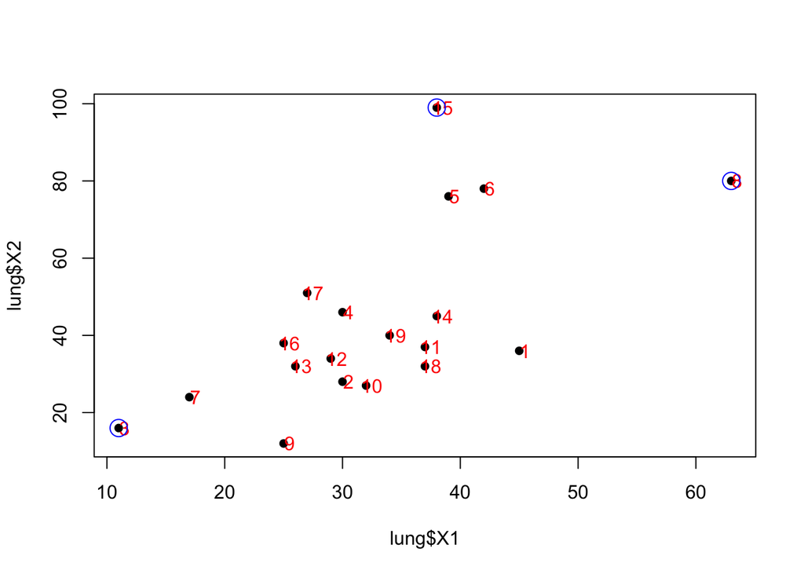

```r
n <- length(lung$Y)
p <-  sum(hii_f2b)
index <- hii_f2b>2*p/n

#index <- influence.measures(f2b)$is.inf[,8]

plot(lung$X1, lung$X2, pch = 16)
text(lung$X1+0.5, lung$X2, labels = as.character(1:length(lung$X1)), col = 'red')
points(lung$X1[index], lung$X2[index], cex = 2.0, col = 'blue')
```

g-) Cases 3, 8, and 15 are moderately far outlying with respect to their X values, and case 7 is relatively far outlying with respect to its Y value. Obtain DFFITS, DFBETAS, and Cook’s distance values for these cases to assess their influence. What do you conclude?

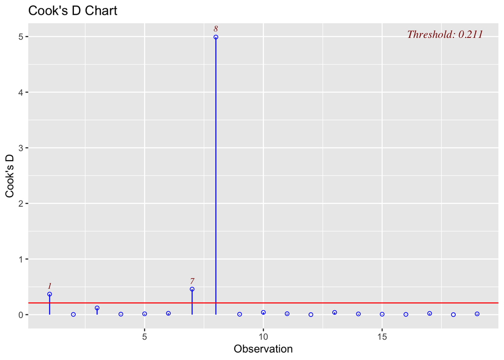

```r
# plot charts
newer.par = par(mfrow = c(2,2))
ols_plot_cooksd_chart(f2b)
```

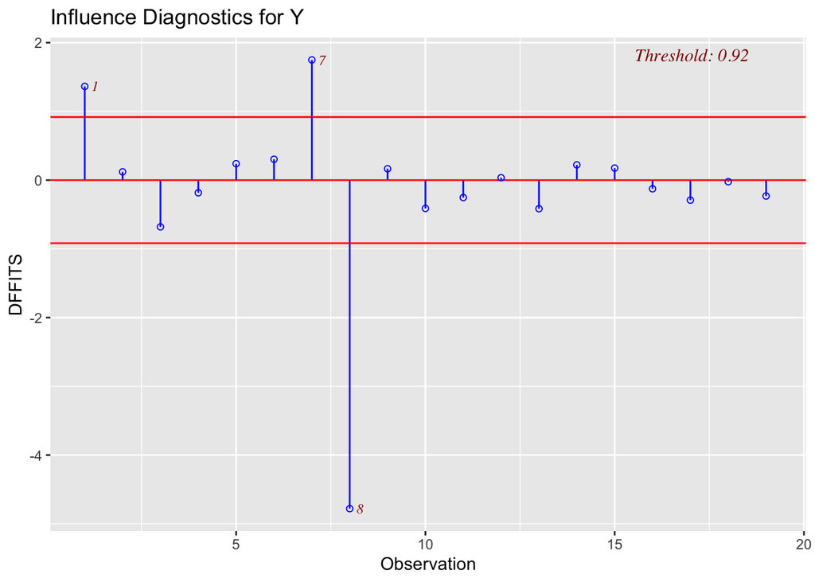

```r
ols_plot_dffits(f2b)
```

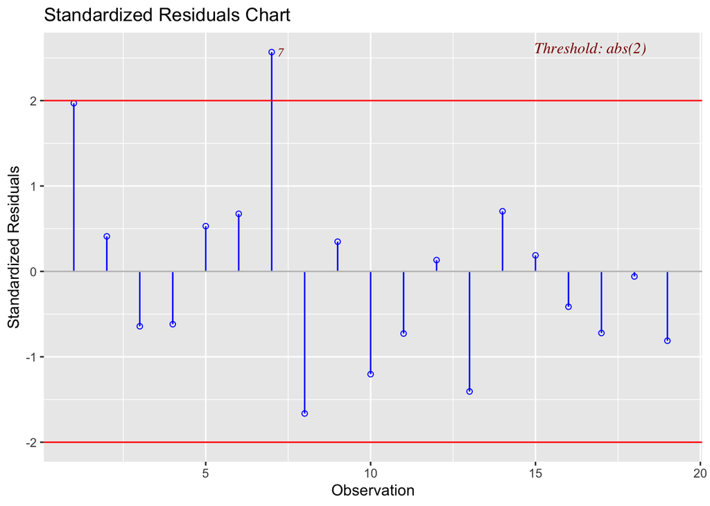

```r
ols_plot_resid_stand(f2b)
```

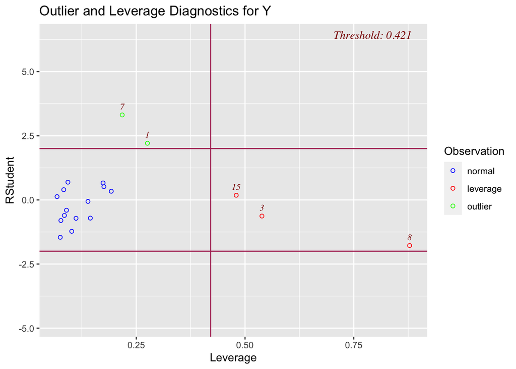

```r
ols_plot_resid_lev(f2b)
```

```r
newer.par
```

```
## $mfrow
## [1] 1 1
```

```r
# get their values
influence.measures(f2b)$infmat[3,]
```

```
##     dfb.1_     dfb.X1     dfb.X2   dfb.X1:X      dffit      cov.r     cook.d
## -0.6519371  0.5919134  0.4333718 -0.4819110 -0.6801824  2.5561254  0.1205155
##        hat
##  0.5388667
```

```r
influence.measures(f2b)$infmat[8,]
```

```
##     dfb.1_     dfb.X1     dfb.X2   dfb.X1:X      dffit      cov.r     cook.d
## -1.5469080  1.1866225  3.1622653 -3.2857900 -4.7797848  4.7895257  4.9908150
##        hat
##  0.8782787
```

```r
influence.measures(f2b)$infmat[7,]
```

```
##     dfb.1_     dfb.X1     dfb.X2   dfb.X1:X      dffit      cov.r     cook.d
##  1.4541305 -1.2776085 -0.7415197  0.8475233  1.7485509  0.1661137  0.4589171
##        hat
##  0.2177509
```

```r
influence.measures(f2b)$infmat[15,]
```

```
##       dfb.1_       dfb.X1       dfb.X2     dfb.X1:X        dffit        cov.r
## -0.015505900 -0.035251060  0.077147027 -0.015699767  0.174857335  2.509527439
##       cook.d          hat
##  0.008170411  0.479820998
```

## Problem 3

Refer to the Prostate cancer data set. Serum prostate-specific antigen (PSA) was determined in 97 men with advanced prostate cancer. PSA is a well-established screening test for prostate cancer and the oncologists wanted to examine the correlation between level of PSA and a number of clinical measures for men who were about to undergo radical prostatectomy. The measures are cancer volume, prostate weight, patient age, the amount of benign prostatic hyperplasia, seminal vesicle invasion, capsular penetration, and Gleason score. (20 points, 5 points each)

a-) Select a random sample of 65 observations to use as the model-building data set. Develop a best subset model for predicting PSA. Justify your choice of model. Assess your model’s ability to predict and discuss its usefulness to the oncologists.

```r
# load data and create sample
prost <- read.csv('Prostate Cancer.csv')
head(prost)
```

|  | PSA.level | Cancer.volume | Weight | Age | Benign.prostatic.hyperplasia | Seminal.vesicle.invasion | Capsular.penetration | Gleason.score |
| --- | --- | --- | --- | --- | --- | --- | --- | --- |
| 1 | 0.651 | 0.5599 | 15.959 | 50 | 0 | 0 | 0 | 6 |
| 2 | 0.852 | 0.3716 | 27.660 | 58 | 0 | 0 | 0 | 7 |
| 3 | 0.852 | 0.6005 | 14.732 | 74 | 0 | 0 | 0 | 7 |
| 4 | 0.852 | 0.3012 | 26.576 | 58 | 0 | 0 | 0 | 6 |
| 5 | 1.448 | 2.1170 | 30.877 | 62 | 0 | 0 | 0 | 6 |
| 6 | 2.160 | 0.3499 | 25.280 | 50 | 0 | 0 | 0 | 6 |

```r
str(prost)
```

```
## 'data.frame':    97 obs. of  8 variables:
##  $ PSA.level                   : num  0.651 0.852 0.852 0.852 1.448 ...
##  $ Cancer.volume               : num  0.56 0.372 0.601 0.301 2.117 ...
##  $ Weight                      : num  16 27.7 14.7 26.6 30.9 ...
##  $ Age                         : int  50 58 74 58 62 50 64 58 47 63 ...
##  $ Benign.prostatic.hyperplasia: num  0 0 0 0 0 ...
##  $ Seminal.vesicle.invasion    : int  0 0 0 0 0 0 0 0 0 0 ...
##  $ Capsular.penetration        : num  0 0 0 0 0 0 0 0 0 0 ...
##  $ Gleason.score               : int  6 7 7 6 6 6 6 6 7 6 ...
```

```r
set.seed(567)
ind <- sample(1:nrow(prost), 65)
ptrain <- prost[ind,]
ptest <- prost[-ind,]

# select best subset - we don't use interaction terms since the notebook was running for an hour with no results
f3a <- lm(PSA.level~., data = ptrain)
summary(f3a)
```

```
##
## Call:
## lm(formula = PSA.level ~ ., data = ptrain)
##
## Residuals:
##     Min      1Q  Median      3Q     Max
## -58.959 -10.534   0.546   7.886 136.999
##
## Coefficients:
##                              Estimate Std. Error t value Pr(>|t|)
## (Intercept)                   36.0596    48.0216   0.751  0.45580
## Cancer.volume                  1.2769     0.6998   1.825  0.07327 .
## Weight                         0.4520     0.2845   1.589  0.11765
## Age                           -1.2624     0.5821  -2.169  0.03429 *
## Benign.prostatic.hyperplasia  -0.5805     1.6757  -0.346  0.73029
## Seminal.vesicle.invasion      -6.8214    13.9254  -0.490  0.62612
## Capsular.penetration           4.7785     1.5119   3.161  0.00252 **
## Gleason.score                  4.2182     5.7792   0.730  0.46844
## ---
## Signif. codes:  0 '***' 0.001 '**' 0.01 '*' 0.05 '.' 0.1 ' ' 1
##
## Residual standard error: 28.31 on 57 degrees of freedom
## Multiple R-squared:  0.5555, Adjusted R-squared:  0.5009
## F-statistic: 10.17 on 7 and 57 DF,  p-value: 3.443e-08
```

```r
b3 <- ols_step_best_subset(f3a, details = TRUE)
b3
```

|  | mindex | n | predictors | rsquare | adjr | predrsq | cp | aic | sbic | sbc | msep | fpe | apc | hsp |
| --- | --- | --- | --- | --- | --- | --- | --- | --- | --- | --- | --- | --- | --- | --- |
| 6 | 1 | 1 | Capsular.penetration | 0.4415831 | 0.4327193 | 0.2350809 | 10.599980 | 631.3454 | 446.4976 | 637.8685 | 59188.11 | 938.5900 | 0.5938720 | 14.68665 |
| 12 | 2 | 2 | Cancer.volume Capsular.penetration | 0.5046161 | 0.4886359 | 0.2953337 | 4.517918 | 625.5601 | 441.2370 | 634.2577 | 53367.85 | 858.7016 | 0.5433243 | 13.45603 |
| 36 | 3 | 3 | Cancer.volume Age Capsular.penetration | 0.5219976 | 0.4984893 | 0.2891247 | 4.289258 | 625.2385 | 441.2535 | 636.1104 | 52353.58 | 854.5400 | 0.5406912 | 13.41669 |
| 66 | 4 | 4 | Cancer.volume Weight Age Capsular.penetration | 0.5487088 | 0.5186227 | 0.3087414 | 2.864370 | 623.5008 | 440.2416 | 636.5471 | 50265.79 | 832.1216 | 0.5265065 | 13.09634 |
| 104 | 5 | 5 | Cancer.volume Weight Age Capsular.penetration Gleason.score | 0.5528814 | 0.5149900 | 0.2978501 | 4.329359 | 624.8970 | 442.0048 | 640.1178 | 50659.67 | 850.3784 | 0.5380580 | 13.42268 |
| 123 | 6 | 6 | Cancer.volume Weight Age Seminal.vesicle.invasion Capsular.penetration Gleason.score | 0.5545140 | 0.5084293 | 0.2452431 | 6.120018 | 626.6593 | 444.0906 | 644.0544 | 51360.20 | 874.0205 | 0.5530171 | 13.84292 |
| 127 | 7 | 7 | Cancer.volume Weight Age Benign.prostatic.hyperplasia Seminal.vesicle.invasion Capsular.penetration Gleason.score | 0.5554501 | 0.5008562 | 0.2382498 | 8.000000 | 628.5225 | 446.2667 | 648.0920 | 52167.51 | 899.8117 | 0.5693359 | 14.30718 |

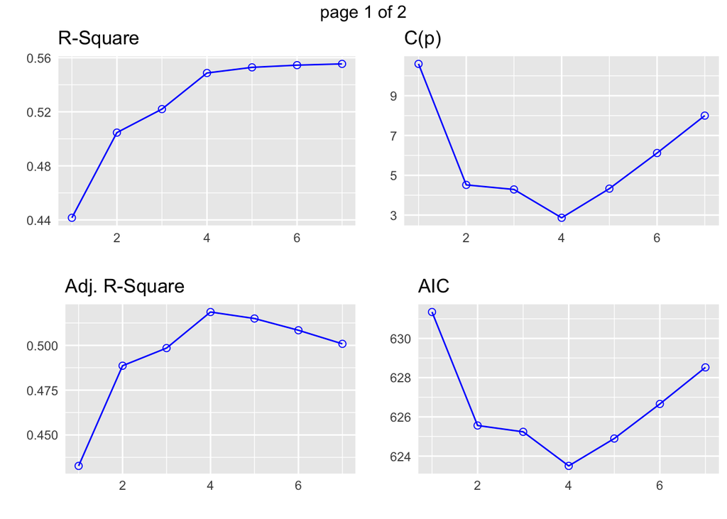

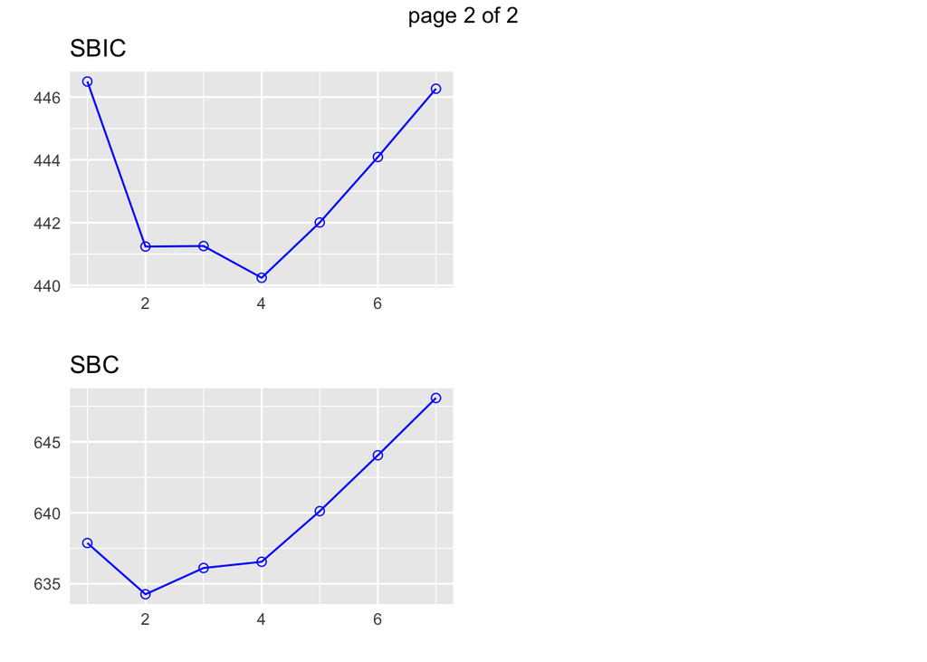

```r
plot(b3)
```

```r
which.max(b3$rsquare)
```

```
## [1] 7
```

```r
which.min(b3$aic)
```

```
## [1] 4
```

```r
which.min(b3$cp)
```

```
## [1] 4
```

```r
# Create a separate dataframe with calculations
aic_ptrain_cols <- unlist(strsplit(b3$predictors[which.min(b3$aic)], split = ' '))
aic_ptrain_cols
```

```
## [1] "Cancer.volume"        "Weight"               "Age"
## [4] "Capsular.penetration"
```

```r
aic_ptrain_df <- ptrain[aic_ptrain_cols]
ptrain_can <- ptrain$PSA.level
aic_ptrain_df <- cbind(ptrain_can, aic_ptrain_df)
head(aic_ptrain_df)
```

|  | ptrain_can | Cancer.volume | Weight | Age | Capsular.penetration |
| --- | --- | --- | --- | --- | --- |
| 13 | 3.561 | 5.0028 | 20.491 | 63 | 0.5488 |
| 28 | 6.172 | 0.6703 | 47.942 | 67 | 0.0000 |
| 69 | 19.298 | 0.6376 | 82.269 | 69 | 0.0000 |
| 71 | 20.287 | 6.4237 | 36.234 | 60 | 3.7434 |
| 87 | 39.646 | 7.5383 | 41.679 | 58 | 0.0000 |
| 46 | 12.807 | 5.2593 | 29.666 | 61 | 0.0000 |

```r
# regression
f3b <- lm(ptrain_can~., data = aic_ptrain_df)

# build final model through 10 fold CV
#control3b <- trainControl(method = 'cv', number = 10)
#f3b <- train(ptrain_can~., data = aic_ptrain_df, method = 'lm', trControl = control3b, metric = 'Rsquared')

summary(f3b)
```

```
##
## Call:
## lm(formula = ptrain_can ~ ., data = aic_ptrain_df)
##
## Residuals:
##     Min      1Q  Median      3Q     Max
## -58.871  -8.535   0.807   8.136 139.070
##
## Coefficients:
##                      Estimate Std. Error t value Pr(>|t|)
## (Intercept)           63.7453    33.1920   1.921 0.059551 .
## Cancer.volume          1.4096     0.6078   2.319 0.023813 *
## Weight                 0.3858     0.2047   1.884 0.064346 .
## Age                   -1.2444     0.5633  -2.209 0.030994 *
## Capsular.penetration   4.4643     1.2669   3.524 0.000821 ***
## ---
## Signif. codes:  0 '***' 0.001 '**' 0.01 '*' 0.05 '.' 0.1 ' ' 1
##
## Residual standard error: 27.8 on 60 degrees of freedom
## Multiple R-squared:  0.5487, Adjusted R-squared:  0.5186
## F-statistic: 18.24 on 4 and 60 DF,  p-value: 7.512e-10
```

b-) Perform appropriate diagnostic checks to evaluate outliers and assess their influence.

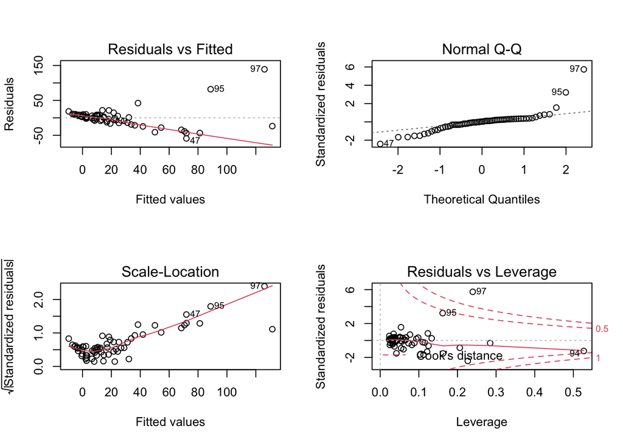

```r
# Basic plots
newer.par = par(mfrow = c(2,2))
plot(f3b)
```

```r
newer.par
```

```
## $mfrow
## [1] 1 1
```

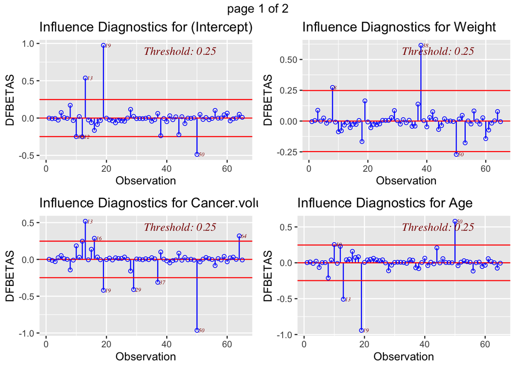

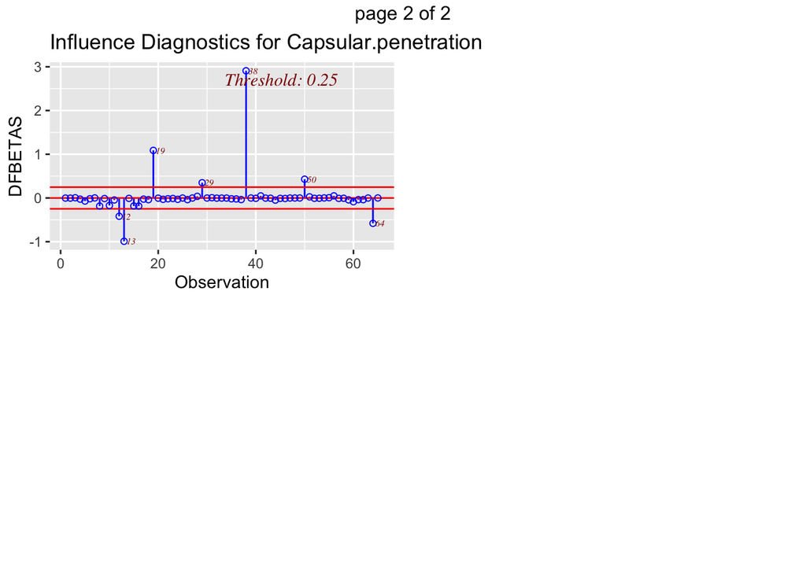

```r
# plot charts
ols_plot_dfbetas(f3b)
```

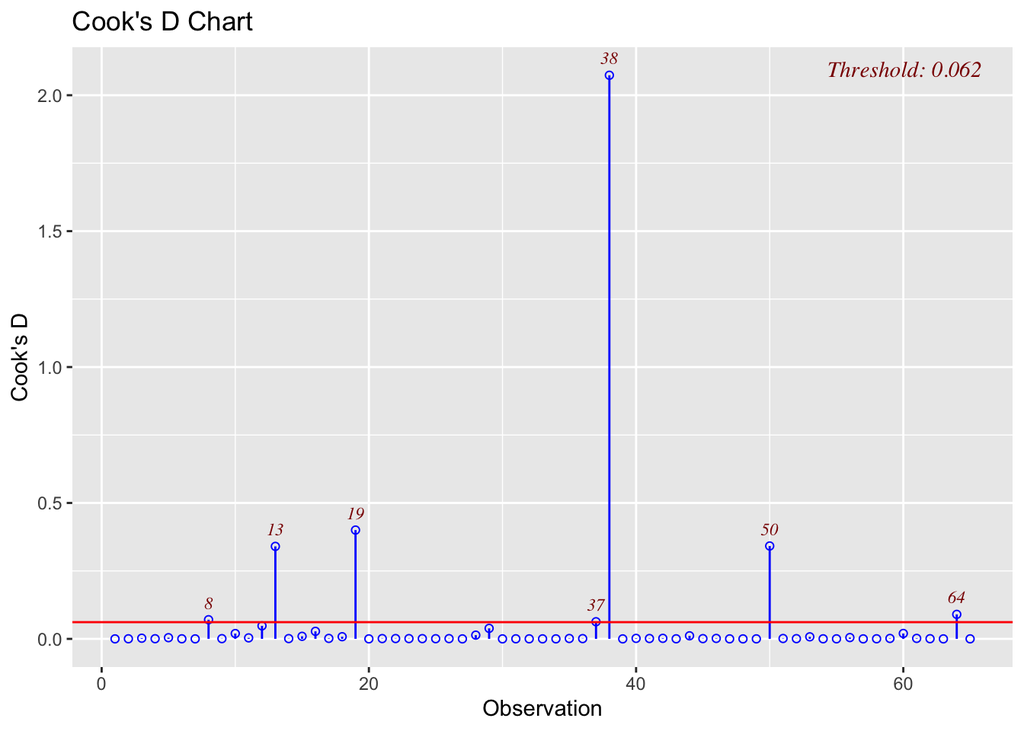

```r
ols_plot_cooksd_chart(f3b)
```

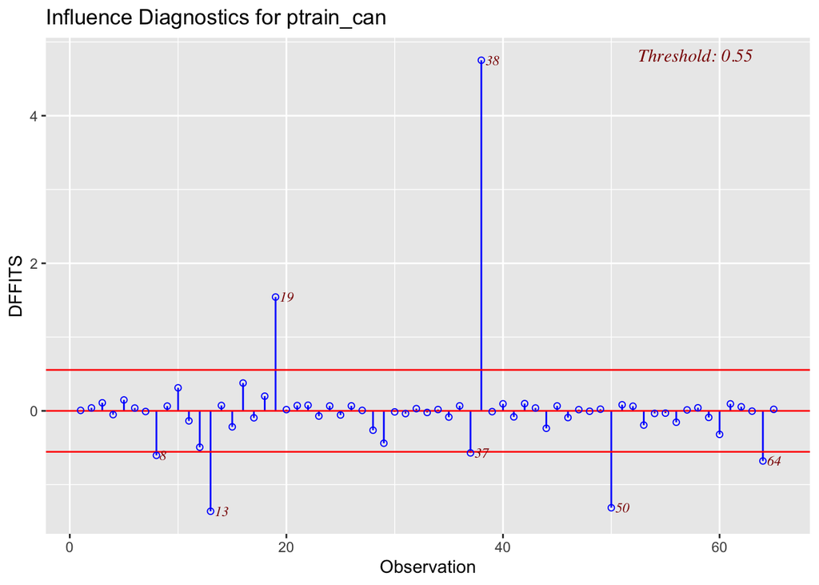

```r
ols_plot_dffits(f3b)
```

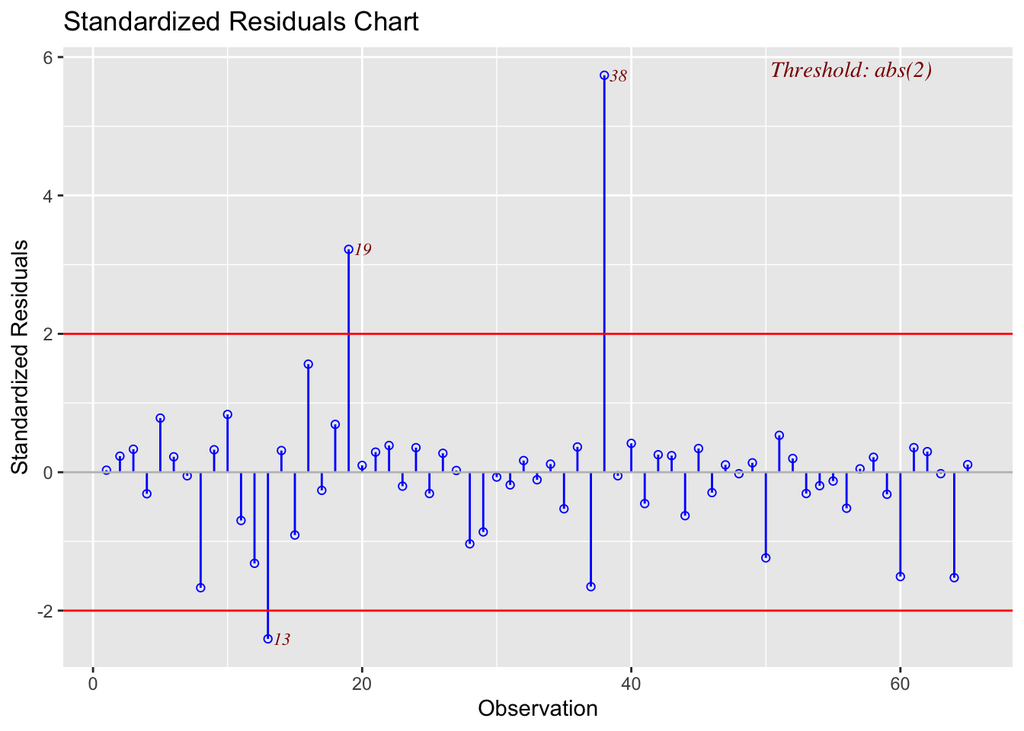

```r
ols_plot_resid_stand(f3b)
```

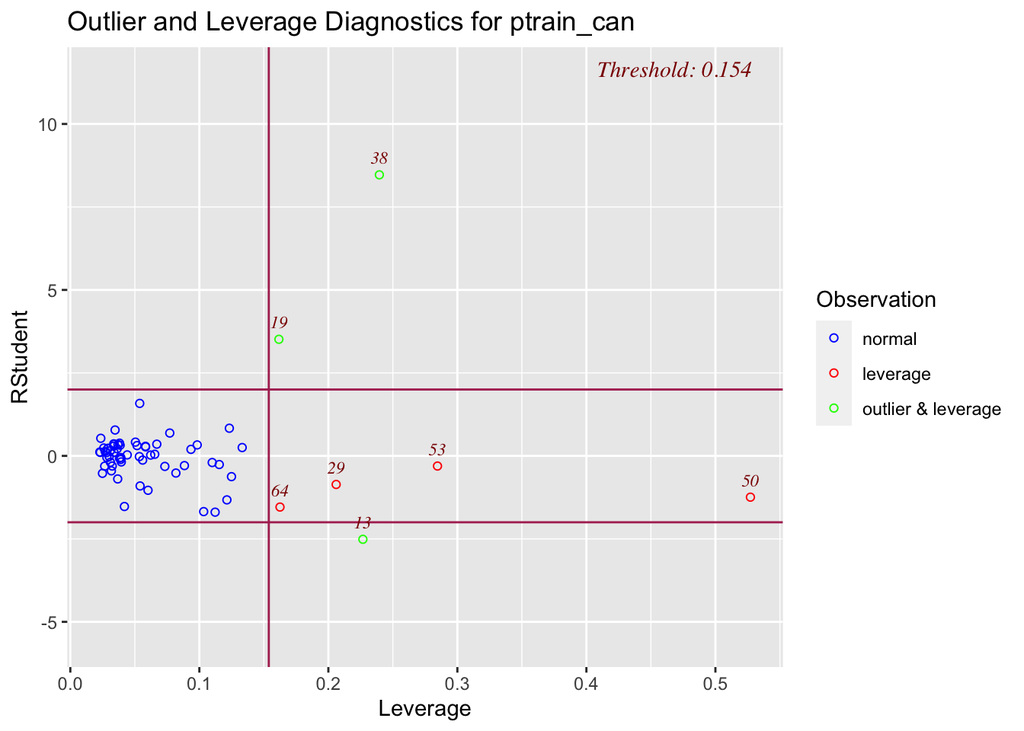

```r
ols_plot_resid_lev(f3b)
```

```r
# get hat values & plot
hii_f3b <- hatvalues(f3b)
hii_f3b
```

```
##         13         28         69         71         87         46         21
## 0.04411156 0.02928618 0.09834102 0.02663408 0.03469374 0.02900184 0.02836806
##         76         20         83         54         82         47         29
## 0.11224496 0.03861990 0.12325928 0.03672020 0.12136602 0.22677957 0.05171245
##         62         93         57         38         95          7         16
## 0.05407470 0.05378998 0.11544445 0.07708602 0.16167430 0.02802892 0.05826462
##         25         58         42         15         68         56         75
## 0.03815161 0.10997838 0.03399091 0.03247742 0.05835099 0.06228609 0.06023819
##         55          2         36         48         31         66         44
## 0.20605975 0.03808943 0.03952392 0.03127004 0.03901996 0.02287856 0.02491260
##         45         86         97          4         17         18         61
## 0.03365811 0.10336382 0.23952815 0.03916000 0.05046839 0.03182245 0.13321461
##         60          9         41          1         27         34         12
## 0.02593289 0.12491796 0.03691804 0.08844278 0.02323069 0.05351648 0.02701140
##         94         85         77         70          8         52         63
## 0.52713801 0.02361915 0.09352031 0.28459320 0.03108993 0.05606891 0.08183991
##         80         10         37         39         14         65         74
## 0.06545673 0.03633421 0.07326654 0.04193092 0.06703298 0.03370611 0.03013283
##         79         23
## 0.16252141 0.03383339
```

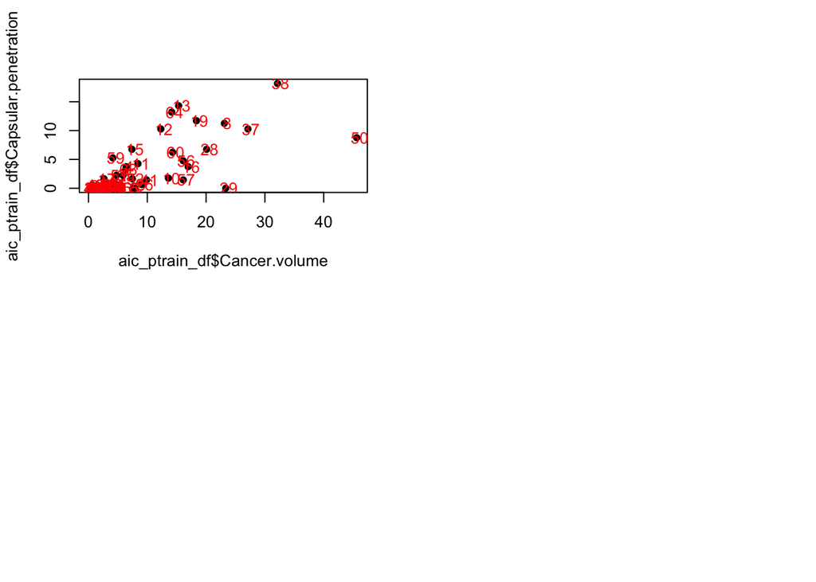

```r
n <- length(aic_ptrain_df)
p <-  sum(hii_f3b)
index <- hii_f3b>2*p/n

#index <- influence.measures(f2b)$is.inf[,8]

plot(aic_ptrain_df$Cancer.volume, aic_ptrain_df$Capsular.penetration, pch = 16)
text(aic_ptrain_df$Cancer.volume+0.5, aic_ptrain_df$Capsular.penetration, labels = as.character(1:nrow(aic_ptrain_df)), col = 'red')
points(aic_ptrain_df$Cancer.volume[index], aic_ptrain_df$Capsular.penetration[index], cex = 2.0, col = 'blue')
```

c-) Fit the regression model identified in part a to the validation data set. Compare the estimated regression coefficients and their estimated standard errors with those obtained in part a. Also compare the error mean square and coefficients of multiple determination. Does the model fitted to the validation data set yield similar estimates as the model fitted to the model-building data set?

```r
aic_ptest_df <- ptest[aic_ptrain_cols]
ptest_can <- ptest$PSA.level
aic_ptest_df <- cbind(ptest_can, aic_ptest_df)
head(aic_ptest_df)
```

|  | ptest_can | Cancer.volume | Weight | Age | Capsular.penetration |
| --- | --- | --- | --- | --- | --- |
| 3 | 0.852 | 0.6005 | 14.732 | 74 | 0.0000 |
| 5 | 1.448 | 2.1170 | 30.877 | 62 | 0.0000 |
| 6 | 2.160 | 0.3499 | 25.280 | 50 | 0.0000 |
| 11 | 3.561 | 1.2840 | 36.598 | 65 | 0.0000 |
| 19 | 4.759 | 0.5712 | 26.311 | 41 | 0.0000 |
| 22 | 5.259 | 7.8460 | 33.115 | 60 | 3.8574 |

```r
# regression
f3d <- lm(ptest_can~., data = aic_ptest_df)
summary(f3d)
```

```
##
## Call:
## lm(formula = ptest_can ~ ., data = aic_ptest_df)
##
## Residuals:
##     Min      1Q  Median      3Q     Max
## -50.296 -15.280  -1.464   5.586 164.483
##
## Coefficients:
##                        Estimate Std. Error t value Pr(>|t|)
## (Intercept)          -21.974888  52.487102  -0.419  0.67877
## Cancer.volume          4.047168   1.272850   3.180  0.00368 **
## Weight                -0.009446   0.088416  -0.107  0.91571
## Age                    0.363584   0.819275   0.444  0.66073
## Capsular.penetration   0.194860   2.716593   0.072  0.94335
## ---
## Signif. codes:  0 '***' 0.001 '**' 0.01 '*' 0.05 '.' 0.1 ' ' 1
##
## Residual standard error: 36.85 on 27 degrees of freedom
## Multiple R-squared:  0.3531, Adjusted R-squared:  0.2572
## F-statistic: 3.684 on 4 and 27 DF,  p-value: 0.01613
```

```r
rbind(f3b$coefficients, f3d$coefficients)
```

```
##      (Intercept) Cancer.volume       Weight        Age Capsular.penetration
## [1,]    63.74527      1.409619  0.385796532 -1.2444182              4.46431
## [2,]   -21.97489      4.047168 -0.009445726  0.3635843              0.19486
```

As seen above the coefficients are very different for the test and validation sets.

Train set has a R2 of 0.55 while test set has R2 of 0.35.

d-) Calculate the mean squared prediction error and compare it to MSE obtained from the model-building data set. Is there evidence of a substantial bias problem in MSE here?

```r
# predict on train set and get summary
predict_ptrain <- predict(f3b, ptrain)
model_ptrain <- data.frame(obs = ptrain$PSA.level, pred = predict_ptrain)
defaultSummary(model_ptrain)
```

```
##       RMSE   Rsquared        MAE
## 26.7066863  0.5487088 15.6680275
```

```r
# predict on test set and get summary
predict_ptest <- predict(f3b, ptest)
model_ptest <- data.frame(obs = ptest$PSA.level, pred = predict_ptest)
defaultSummary(model_ptest)
```

```
##        RMSE    Rsquared         MAE
## 49.32220375  0.03498288 28.63857858
```

The test model has higher error metrics as compared to the train set.